# Statistical Techniques for Analizing Data in R

Fernando Barranco R

August 11, 2017

## Part 1: Simulation

Comparition between the exponential distribution in R and the Central Limit Theorem. The exponential distribution has two parameters: ‘lambda’: the rate parameter and ‘n’: the number of observations. The mean of an exponential distribution is 1/lambda, the standard deviation is also 1/lambda.

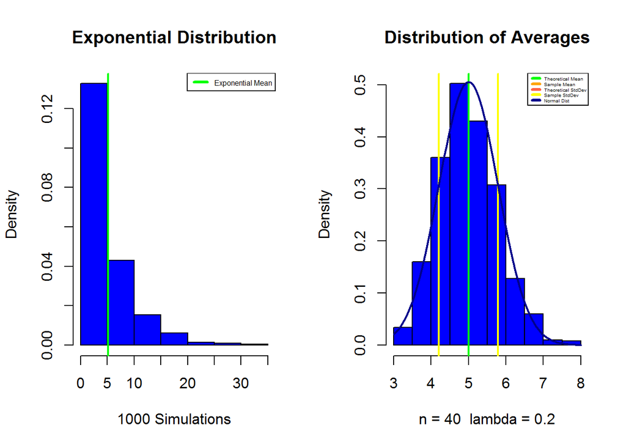

```r
# Number of observations
n <- 40

# Mean and Std Deviation 'lambda'
lambda <- 0.2

# Number of simulations
sim <- 1000

# Defining an empty vector
vect <- as.numeric()

# Looping a 1000 simulations
for (i in 1:sim){
        vect <- c(vect, mean(rexp(n, lambda)) ) }

# Creating a plotting environment
par(mfrow = c(1,2))

# Pseudo random number, for reproducibilty sake
set.seed(12345)

# First plot (Exponenctial Distribution)
hist(rexp(sim, lambda), col = "blue", xlab = "1000 Simulations",
     main = "Exponential Distribution", freq = FALSE)
abline(v= mean(rexp(sim, lambda)), col = "green", lwd = 2)
legend(x = "topright", legend = "Exponential Mean", col = "green", lty = 1,
       lwd = 3, cex = 0.5)

# Second plot (Distribution of Averages)
hist(vect, col = "blue", main = "Distribution of Averages",
     breaks = 10, xlab = "n = 40  lambda = 0.2", freq = FALSE)
abline(v = mean(vect), col = "orange", lwd = 2)
abline(v = 1/lambda, col = "green", lwd = 2)
abline(v = sd(vect)*c(-1,1)+mean(vect), col = "tomato", lwd = 2)
abline(v = (1/lambda)/sqrt(n)*c(-1,1)+(1/lambda), col = "yellow", lwd = 2)
curve(dnorm(x, mean = mean(vect), sd = sd(vect)), col = "darkblue", lwd = 2, add = TRUE)
legend(x = "topright", lty = 1, cex = 0.3, lwd = 3,
       col = c("green", "orange", "tomato", "yellow", "darkblue"),
       legend = c("Theoretical Mean", "Sample Mean", "Theoretical StdDev",
                  "Sample StdDev", "Normal Dist"))
```

- Show the sample mean and compare it to the theoretical mean of the distribution.

```r
sample.mean <- mean(vect)
sample.mean
```

```
## [1] 4.997414
```

```r
theoretical.mean <- 1/lambda
theoretical.mean
```

```
## [1] 5
```

- Show how variable the sample is (via variance) and compare it to the theoretical variance of the distribution.

```r
sample.variance <- sd(vect)^2
sample.variance
```

```
## [1] 0.6230125
```

```r
theoretical.variance <- ((1/lambda)/sqrt(n))^2
theoretical.variance
```

```
## [1] 0.625
```

- Show that the distribution is approximately normal.

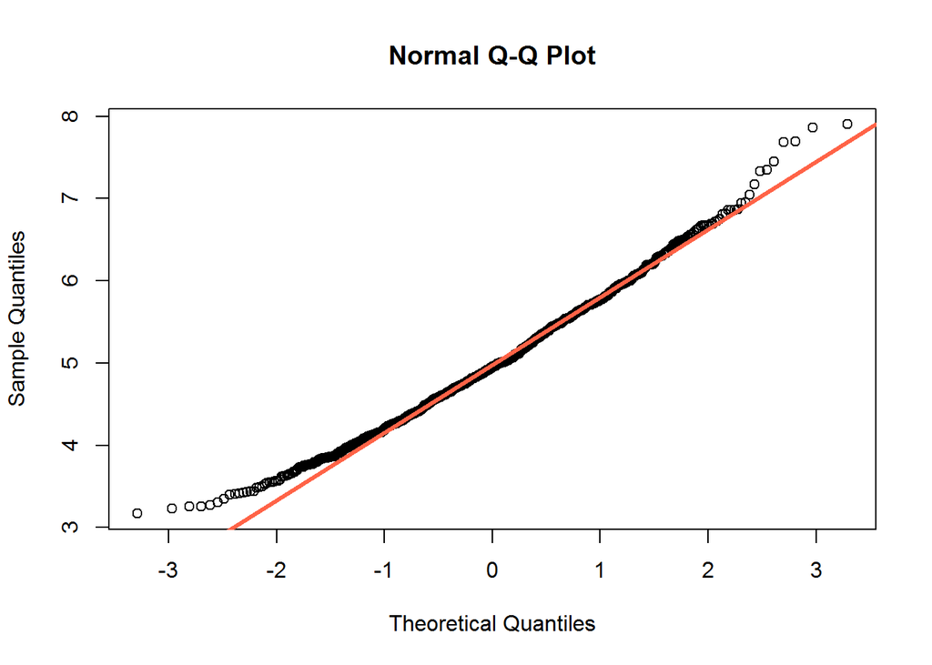

```r
par(mfrow = c(1,1))
qqnorm(vect)
qqline(vect, col = "tomato", lwd = 3)
```

```r
# Interpretation: If the Sample quantiles provide from a Normal Distribution, then it
#                 should be the same as the Theoretical quantiles matching an Identity Line.
```

## Part 2: Inferential Data Analysis

Analyze the ToothGrowth data in the R datasets package.

“The Effect of Vitamin C on Tooth Growth in Guinea Pigs”

*Description:* The response is the length of odontoblasts (cells responsible for tooth growth) in 60 guinea pigs. Each animal received one of three dose levels of vitamin C (0.5, 1, and 2 mg/day) by one of two delivery methods, (orange juice or ascorbic acid (a form of vitamin C and coded as VC).

A data frame with 60 observations on 3 variables.

| Variable | Type | Description |
| --- | --- | --- |
| **len** | numeric | Tooth length |
| **supp** | factor | Supplement type (VC or OJ). |
| **dose** | numeric | Dose in milligrams/day |

- Load the ToothGrowth data and perform some basic exploratory data analyses

```r
Tooth <- datasets::ToothGrowth
Tooth
```

```
##     len supp dose
## 1   4.2   VC  0.5
## 2  11.5   VC  0.5
## 3   7.3   VC  0.5
## 4   5.8   VC  0.5
## 5   6.4   VC  0.5
## 6  10.0   VC  0.5
## 7  11.2   VC  0.5
## 8  11.2   VC  0.5
## 9   5.2   VC  0.5
## 10  7.0   VC  0.5
## 11 16.5   VC  1.0
## 12 16.5   VC  1.0
## 13 15.2   VC  1.0
## 14 17.3   VC  1.0
```

[output cut: 46 more lines]

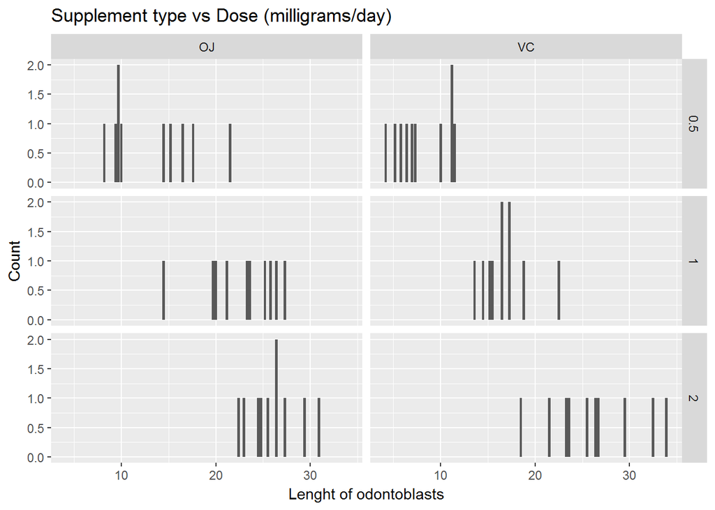

```r
library(ggplot2)

ggplot(Tooth) +
        geom_bar(aes(len)) +
        facet_grid(dose ~ supp) +
        theme_set(theme_bw()) +
        labs(x = "Lenght of odontoblasts", y = "Count",
             title = "Supplement type vs Dose (milligrams/day)")
```

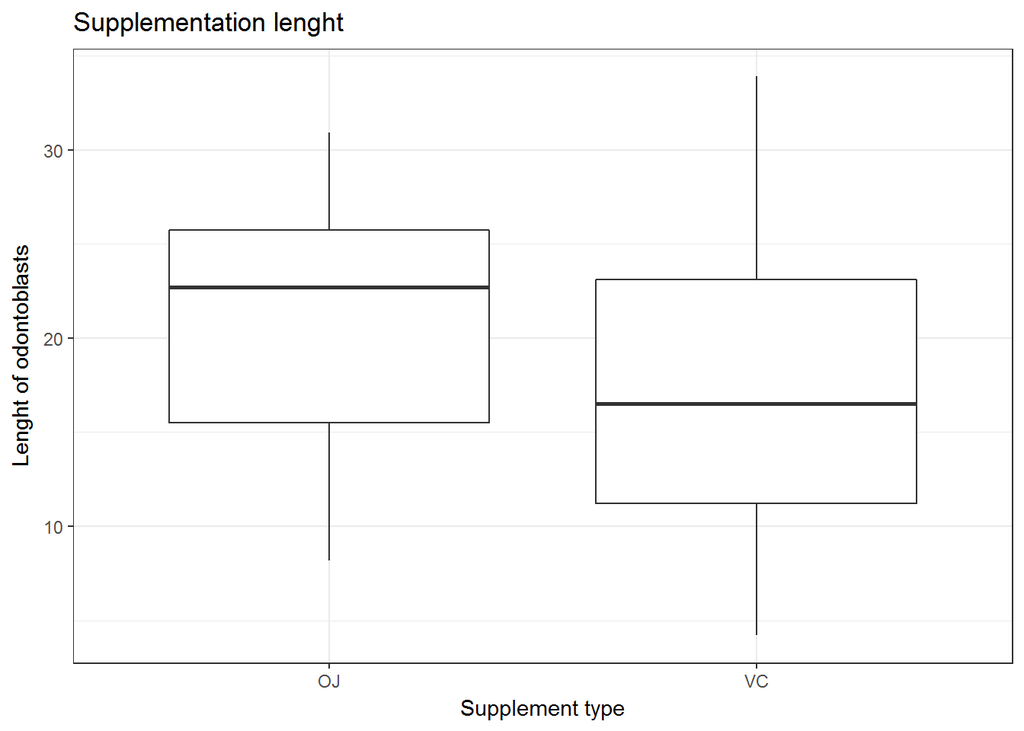

```r
ggplot(Tooth, aes(x = supp, y = len)) +
        geom_boxplot() +
        theme_set(theme_bw()) +
        labs(x = "Supplement type", y = "Lenght of odontoblasts",
             title = "Supplementation lenght")
```

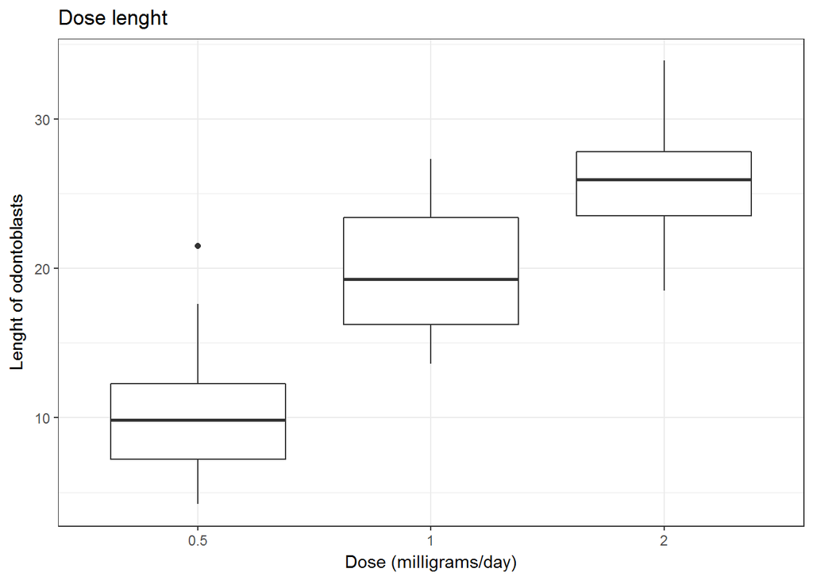

```r
ggplot(Tooth, aes(x = factor(dose), y = len)) +
        geom_boxplot() +
        theme_set(theme_bw()) +
        labs(x = "Dose (milligrams/day)", y = "Lenght of odontoblasts",
             title = "Dose lenght")
```

- Provide a basic summary of the data.

```r
library(dplyr)
Tooth.total <- Tooth %>% group_by(supp, dose) %>%
        summarise(total_len = sum(len))
Tooth.total
```

```
## # A tibble: 6 x 3
## # Groups:   supp [?]
##     supp  dose total_len
##   <fctr> <dbl>     <dbl>
## 1     OJ   0.5     132.3
## 2     OJ   1.0     227.0
## 3     OJ   2.0     260.6
## 4     VC   0.5      79.8
## 5     VC   1.0     167.7
## 6     VC   2.0     261.4
```

- Use confidence intervals and/or hypothesis tests to compare tooth growth by supp and dose. (Only use the techniques from class, even if there’s other approaches worth considering)

We want to know if tooth growth is statistally different by supplement (increase/decrease on average) for each dose, for that purpose we create three different 95% confidence intervals for the mean diference (Orange Juice - Ascorbic Acid).

```r
# Growth by dose of 0.5 milligrams per day
test1 <- Tooth %>% filter(dose == 0.5) %>% print
```

```
##     len supp dose
## 1   4.2   VC  0.5
## 2  11.5   VC  0.5
## 3   7.3   VC  0.5
## 4   5.8   VC  0.5
## 5   6.4   VC  0.5
## 6  10.0   VC  0.5
## 7  11.2   VC  0.5
## 8  11.2   VC  0.5
## 9   5.2   VC  0.5
## 10  7.0   VC  0.5
## 11 15.2   OJ  0.5
## 12 21.5   OJ  0.5
## 13 17.6   OJ  0.5
## 14  9.7   OJ  0.5
## 15 14.5   OJ  0.5
## 16 10.0   OJ  0.5
## 17  8.2   OJ  0.5
## 18  9.4   OJ  0.5
## 19 16.5   OJ  0.5
## 20  9.7   OJ  0.5
```

```r
n_x <- 10 ; n_y <- 10
x_bar <- mean(test1$len[1:10]); y_bar <- mean(test1$len[11:20])
sd_x <- sd(test1$len[1:10]); sd_y <- sd(test1$len[11:20])
alpha <- 0.05
S_p <- sqrt( ((n_x-1)*sd_x^2 + (n_y-1)*sd_y^2) / (n_x+n_y-2) )
t_s <- qt(1-alpha/2, n_x+n_y-2)
round( (y_bar - x_bar) + c(-1, 1) * t_s * S_p * (sqrt(1/n_x + 1/n_y)), 3)
```

```
## [1] 1.77 8.73
```

```r
# Growth by dose of 1.0 milligrams per day
test2 <- Tooth %>% filter(dose == 1) %>% print
```

```
##     len supp dose
## 1  16.5   VC    1
## 2  16.5   VC    1
## 3  15.2   VC    1
## 4  17.3   VC    1
## 5  22.5   VC    1
## 6  17.3   VC    1
## 7  13.6   VC    1
## 8  14.5   VC    1
## 9  18.8   VC    1
## 10 15.5   VC    1
## 11 19.7   OJ    1
## 12 23.3   OJ    1
## 13 23.6   OJ    1
## 14 26.4   OJ    1
## 15 20.0   OJ    1
## 16 25.2   OJ    1
## 17 25.8   OJ    1
## 18 21.2   OJ    1
## 19 14.5   OJ    1
## 20 27.3   OJ    1
```

```r
n_x <- 10 ; n_y <- 10
x_bar <- mean(test2$len[1:10]); y_bar <- mean(test2$len[11:20])
sd_x <- sd(test2$len[1:10]); sd_y <- sd(test2$len[11:20])
alpha <- 0.05
S_p <- sqrt( ((n_x-1)*sd_x^2 + (n_y-1)*sd_y^2) / (n_x+n_y-2) )
t_s <- qt(1-alpha/2, n_x+n_y-2)
round( (y_bar - x_bar) + c(-1, 1) * t_s * S_p * (sqrt(1/n_x + 1/n_y)), 3)
```

```
## [1] 2.841 9.019
```

```r
# Growth by dose of 2.0 milligrams per day
test3 <- Tooth %>% filter(dose == 2) %>% print
```

```
##     len supp dose
## 1  23.6   VC    2
## 2  18.5   VC    2
## 3  33.9   VC    2
## 4  25.5   VC    2
## 5  26.4   VC    2
## 6  32.5   VC    2
## 7  26.7   VC    2
## 8  21.5   VC    2
## 9  23.3   VC    2
## 10 29.5   VC    2
## 11 25.5   OJ    2
## 12 26.4   OJ    2
## 13 22.4   OJ    2
## 14 24.5   OJ    2
## 15 24.8   OJ    2
## 16 30.9   OJ    2
## 17 26.4   OJ    2
## 18 27.3   OJ    2
## 19 29.4   OJ    2
## 20 23.0   OJ    2
```

```r
n_x <- 10 ; n_y <- 10
x_bar <- mean(test3$len[1:10]); y_bar <- mean(test3$len[11:20])
sd_x <- sd(test3$len[1:10]); sd_y <- sd(test3$len[11:20])
alpha <- 0.05
S_p <- sqrt( ((n_x-1)*sd_x^2 + (n_y-1)*sd_y^2) / (n_x+n_y-2) )
t_s <- qt(1-alpha/2, n_x+n_y-2)
round( (y_bar - x_bar) + c(-1, 1) * t_s * S_p * (sqrt(1/n_x + 1/n_y)), 3)
```

```
## [1] -3.723  3.563
```

- State your conclusions and the assumptions needed for your conclusions.

| Test | Dose | Confidence Interval | Interpretation |
| --- | --- | --- | --- |
| 1 | 0.5 | 1.77 - 8.73 | For a dose level of 0.5 mg/day of vitamine c, the orange juice produces a bigger growth on the length of odontoblasts than ascorbic acid. |
| 2 | 1.0 | 2.841 - 9.019 | For a dose level of 1.0 mg/day of vitamine c, the orange juice produces a bigger growth on the length of odontoblasts than ascorbic acid. |
| 3 | 2.0 | -3.723 - 3.563 | For a dose level of 2.0 mg/day of vitamine c, the orange juice produces the same growth on the length of odontoblasts (on average)than ascorbic acid. |